# DATA607 Project 4

Gabriel Campos

May 02 2021

# Assignment

## Requirements

It can be useful to be able to classify new “test” documents using already classified “training” documents. A common example is using a corpus of labeled spam and ham (non-spam) e-mails to predict whether or not a new document is spam.

For this project, you can start with a spam/ham dataset, then predict the class of new documents (either withheld from the training dataset or from another source such as your own spam folder). [Example corpus.](https://spamassassin.apache.org/old/publiccorpus/)

Here are two short videos that you may find helpful.

[video not shown]

The second video provides a short overview of predictive classifiers.

[video not shown]

For more adventurous students, you are welcome (encouraged!) to come up with a different set of documents (including scraped web pages!?) that have already been classified (e.g. tagged), then analyze these documents to predict how new documents should be classified.

**New! Project 4 extra credit!** Students who use the relatively new tidymodels and textrecipes packages to complete their Project 4 work will automatically receive 5 extra credit points. tidymodels is a significant improvement over Max Kuhn’s older `caret` package. Here are some resources to help you get up to speed on tidymodels and textrecipes.

- [Tidy Modeling with R, Max Kuhn and Julia Silge](https://www.tmwr.org/). Julia Silge has also done a number of tidymodels screencasts, including [here](https://www.youtube.com/watch?v=BgWCuyrwD1s)
- github.com/tidymodels/textrecipes
- DataCamp course, [Modeling with TidyModels in R](https://learn.datacamp.com/courses/modeling-with-tidymodels-in-r)

## Data Preparation

### Load Data

URL of file and filename is set by `URL_easy_ham` and `tar_easy_ham` respectively.

```r
#easy_ham.tar.bz2 import
URL_easy_ham =
  "http://spamassassin.apache.org/old/publiccorpus/20021010_easy_ham.tar.bz2"
tar_easy_ham = "20021010_easy_ham.tar.bz2"
dir_easy_ham      = "unzipped_files\\easy_ham\\"

URL_spam =
  "http://spamassassin.apache.org/old/publiccorpus/20021010_spam.tar.bz2"
tar_spam     = "20021010_spam.tar.bz2"
dir_spam     = "unzipped_files\\spam\\"
```

```r
# ham zip file download
download.file(url = URL_easy_ham, destfile = tar_easy_ham)
untar(tar_easy_ham, exdir="unzipped_files", compressed = "bzip2")
files_easy_ham = list.files(path = dir_easy_ham,full.names = TRUE)
```

```r
# spam zip file download
download.file(url = URL_spam, destfile = tar_spam)
untar(tar_spam, exdir="unzipped_files", compressed = "bzip2")
files_spam = list.files(path = dir_spam,full.names = TRUE)
```

`list.files` is also used with several piping functions (`%>%`) to create a data frame with `email_ID`, `text`, `class`, and `double` value `spam` column as shown below for the `easy_ham` data. This step is repeated with `spam` data as well.

```r
df_easy_ham <-
  list.files(path = dir_easy_ham) %>%
    as.data.frame() %>%
      set_colnames("email_ID") %>%
        mutate(text = lapply(files_easy_ham, read_lines)) %>%
          unnest(c(text)) %>%
            mutate(class = "ham",
                  spam = 0) %>%
                    group_by(email_ID) %>%
            mutate(text = paste(text, collapse = " ")) %>%
                            ungroup() %>%
                              distinct()
```

```r
df_spam <-
  list.files(path = dir_spam) %>%
    as.data.frame() %>%
      set_colnames("email_ID") %>%
        mutate(text = lapply(files_spam, read_lines)) %>%
          unnest(c(text)) %>%
            mutate(class = "spam",
                  spam = 1) %>%
                    group_by(email_ID) %>%
            mutate(text = paste(text, collapse = " ")) %>%
                            ungroup() %>%
                              distinct()
```

### Create Classification & Naives Models

Both dataframes are merged using `rbind`.

```r
df_easy_ham_spam <- rbind(df_easy_ham, df_spam)
```

Afterwards, using the [`tidymodels package`](https://www.tidymodels.org/packages/), we create a single binary split of our merged dataframe `df_easy_ham_spam`, with [`initial_split()`](https://www.rdocumentation.org/packages/rsample/versions/0.0.9/topics/initial_split), specifying `strata = class`, making the `class` column our stratified sample. This is used to separate the data into [*training* and *testing*](https://www.r-bloggers.com/2019/06/a-gentle-introduction-to-tidymodels/) sets in conjunction with the `training()` and `testing()` functions, as shown below.

```r
set.seed(3239)
df_split    <- initial_split(df_easy_ham_spam, strata = class)
df_train    <- training(df_split)
df_test     <- testing(df_split)
```

```
## [1] "Training dimensions are "
```

```
## [1] "2290" "4"
```

```
## [1] "Test dimensions are "
```

```
## [1] "762" "4"
```

Using the [`recipe()`](https://www.rdocumentation.org/packages/recipes/versions/0.1.16/topics/recipe) also a part of `tidymodels` we lay out the description to be applied to our data sets. This is in preparation for the processing and tokenizing of the data.

```r
df_rec <-
  recipe(class ~ text, data = df_train)
```

```r
df_rec <- df_rec %>%
  step_tokenize(text) %>%
  step_tokenfilter(text, max_tokens = 10) %>%
  step_tfidf(text)
```

From this point the tokenized data is used in [`add_recipe`](https://www.rdocumentation.org/packages/workflows/versions/0.2.2/topics/add_recipe), to specify the terms of the workflow allow it to be added to a container with [`workflow()`](https://www.rdocumentation.org/packages/workflows/versions/0.1.1/topics/workflow), and stored to `df_wf`

```r
df_wf <- workflow() %>%
  add_recipe(df_rec)
```

```r
(nb_spec <- naive_Bayes() %>%
  set_mode("classification") %>%
  set_engine("naivebayes"))
```

```
## Naive Bayes Model Specification (classification)
##
## Computational engine: naivebayes
```

```r
nb_fit <- df_wf %>%
  add_model(nb_spec) %>%
  fit(data = df_train)
```

## Evaluation

In order to use the Bayes classifcation we start by using [`vfold_cv()`](https://www.rdocumentation.org/packages/rsample/versions/0.0.9/topics/vfold_cv) to split the data randomly, into 10 equal sized folds, then again store it into a container with `workflow()`, `add_recipe()` and `add_model()`

```r
set.seed(234)
(df_folds <- vfold_cv(df_train))
```

```
## #  10-fold cross-validation
## # A tibble: 10 x 2
##    splits             id
##    <list>             <chr>
##  1 <split [2061/229]> Fold01
##  2 <split [2061/229]> Fold02
##  3 <split [2061/229]> Fold03
##  4 <split [2061/229]> Fold04
##  5 <split [2061/229]> Fold05
##  6 <split [2061/229]> Fold06
##  7 <split [2061/229]> Fold07
##  8 <split [2061/229]> Fold08
##  9 <split [2061/229]> Fold09
## 10 <split [2061/229]> Fold10
```

```r
(nb_wf <-
  workflow() %>%
  add_recipe(df_rec) %>%
  add_model(nb_spec))
```

```
## == Workflow ====================================================================
## Preprocessor: Recipe
## Model: naive_Bayes()
##
## -- Preprocessor ----------------------------------------------------------------
## 3 Recipe Steps
##
## * step_tokenize()
## * step_tokenfilter()
## * step_tfidf()
##
## -- Model -----------------------------------------------------------------------
## Naive Bayes Model Specification (classification)
##
## Computational engine: naivebayes
```

Performance of the models is estimated by fitting several models, once, in each re-sampled fold and then evaluating on the heldout part.

```r
nb_rs <-
  fit_resamples(
  nb_wf,
  df_folds,
  control =
    control_resamples(save_pred = TRUE)
)
```

Data is extracted with [`collect_metrics()`](https://tune.tidymodels.org/reference/collect_predictions.html) which creates a `.metric` and `.estimator` column unless summarized and [`collect_predictions()`](https://tune.tidymodels.org/reference/collect_predictions.html) which creates predictive value columns.

```r
(nb_rs_metrics <- collect_metrics(nb_rs))
```

```
## # A tibble: 2 x 6
##   .metric  .estimator  mean     n std_err .config
##   <chr>    <chr>      <dbl> <int>   <dbl> <chr>
## 1 accuracy binary     0.798    10  0.0132 Preprocessor1_Model1
## 2 roc_auc  binary     0.769    10  0.0154 Preprocessor1_Model1
```

```r
nb_rs_predictions <- collect_predictions(nb_rs)
```

## Visualizations

The visualizations reflect the results provided from `nb_rs_metrics` which showed:

| .metric | mean |
| --- | --- |
| accuracy | 0.7982533 |
| roc_auc | 0.7694050 |

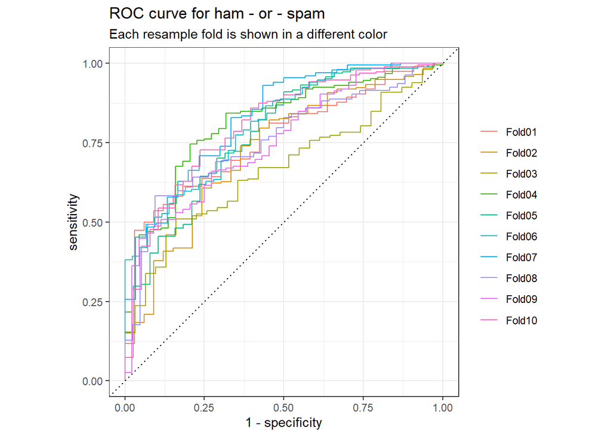

```r
nb_rs_predictions %>%
  group_by(id) %>%
  roc_curve(truth = class, .pred_ham) %>%
  autoplot() +
  labs(
    color = NULL,
    title = "ROC curve for ham - or - spam",
    subtitle = "Each resample fold is shown in a different color"
  )
```

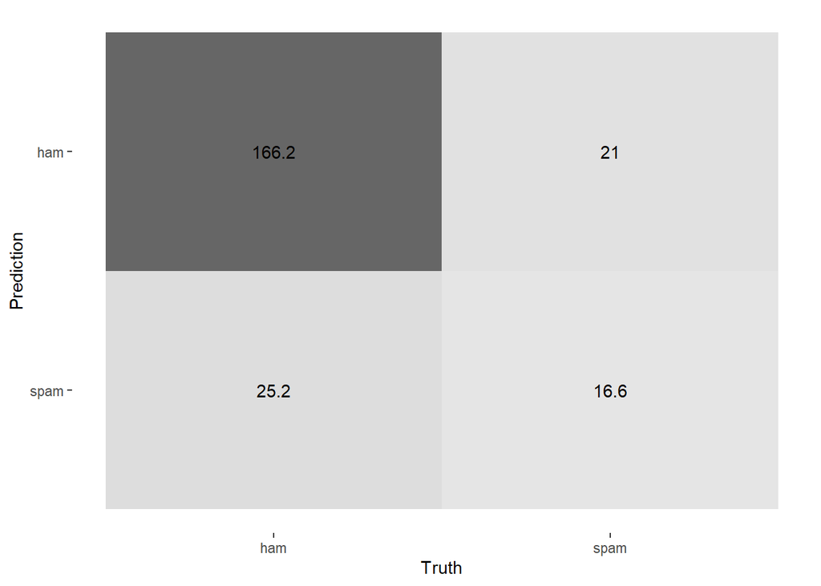

```r
conf_mat_resampled(nb_rs, tidy = FALSE) %>%
  autoplot(type = "heatmap")
```

## Conclusion

The approach in using `tidymodels` and `textrecipe` came primarily from following the layout provided by [$Chapter\ 7: Classification\ |\ Supervised\ Machine\ Learning\ for\ Text\ Analysis\ in\ R$](https://smltar.com/mlclassification.html#classfirstattemptlookatdata). Although the evaluation and data manipulation was done correctly, I would attribute the lower accuracy from the the email details such as *source*, *sender*, etc. In order to expand on and test this theory, a future project with cleaner `text` data should be used, to see if the results differ.